# hw2

```python
%matplotlib inline
from __future__ import division
import pandas as pd
import numpy as np
#from seaborn import plt
import matplotlib.pyplot as plt
from matplotlib.colors import ListedColormap
#
from sklearn.datasets import load_iris
from sklearn import neighbors, datasets, feature_selection
from sklearn.cross_validation import train_test_split, cross_val_score
```

- Question 1: Implement KNN classification, using the sklearn package. We learned how to do this in class. See also: http://scikit-learn.org/stable/modules/neighbors.html#nearest-neighbors-classification

```python
# Load in the data
iris = datasets.load_iris()
iris_df = pd.DataFrame(iris.data, columns=iris.feature_names)
#iris_df.head()
#iris_df.describe()
```

```python
# Various variables we'll need to set intially.
n_neighbors = range(1, 51, 2)
#print type(n_neighbors)
#print n_neighbors
```

```python
# Create the training (and test) set using scikit-learn's train_test_split function
X_train, X_test, y_train, y_test = train_test_split(iris.data, iris.target, test_size=0.3, random_state=12)
```

```python
# Loop through each neighbors value from 1 to 51 and append
# the scores
scores = []
for n in n_neighbors:
    clf = neighbors.KNeighborsClassifier(n)
    clf.fit(X_train, y_train)
    scores.append(clf.score(X_test, y_test))
```

```python
scores_ndarray = np.array(scores)
print scores_ndarray.mean()
```

```
0.962666666667
```

- Question 2. Use the sklearn package to implement cross-validation for your classifier. Use 5 folds for your cross-validation. See also: http://scikit-learn.org/stable/modules/cross_validation.html#

```python
from sklearn.cross_validation import cross_val_score
```

```python
clf = neighbors.KNeighborsClassifier(6, weights='uniform')
clf.fit(iris.data, iris.target)
scores = cross_val_score(clf, iris_df.values, iris.target, cv=5)
```

```python
print scores
print scores.mean()
```

```
[ 0.96666667  1.          0.96666667  0.96666667  1.        ]
0.98
```

- Question 3. Use your KNN classifier and cross-validation code from (1) and (2) above to determine the optimal value of K (number of nearest neighbors to consult) for this Iris dataset. Hint: This hyperparameter will be a number between 1 and 150.

```python
scores_for_dif_k_values = []
for k in range(1,121):
    clf = neighbors.KNeighborsClassifier(k, weights='uniform')
    clf.fit(iris.data, iris.target)
    fold_scores = cross_val_score(clf, iris.data, iris.target, cv=5)
    #print k
    #print fold_scores
    #print fold_scores.mean()
    scores_for_dif_k_values.append(fold_scores.mean())
#print scores_for_dif_k_values
max_k = np.argmax(scores_for_dif_k_values)
#print max_k
#print scores_for_dif_k_values[max_k]
print "Optimal value of K: {}".format(max_k+1)
print "K of {} has {} accuracy".format(max_k+1, scores_for_dif_k_values[max_k])
```

```
Optimal value of K: 6
K of 6 has 0.98 accuracy
```

- Question 4. Using matplotlib, plot classifier accuracy versus the hyperparameter K for a range of K that you consider interesting. Explain in words what you are seeing.

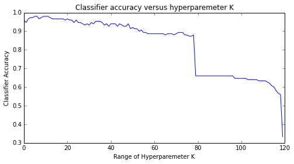

```python
fig = plt.figure(figsize = (8, 4))
ax = fig.add_subplot(1,1,1)
ax.plot(scores_for_dif_k_values)
ax.plot(max_k,scores_for_dif_k_values[max_k])

plt.title('Classifier accuracy versus hyperparemeter K')
plt.xlabel('Range of Hyperparemeter K')
plt.ylabel('Classifier Accuracy')


plt.show()
```

- Question 5. Now, write your own implementation of cross-validation in Python without using the cross-validation methods from sklearn. Cross validation is a very important concept. Implementing it yourself in Python is the best way to learn and understand it. Compare the results of your cross-validation code with your results using the cross-validation in sklearn.

```python
iris = datasets.load_iris()
iris_df = pd.DataFrame(iris.data, columns=iris.feature_names)
iris_df2= iris_df.copy()
#add column to dataframe with target values
iris_df2['Target'] = iris.target
#takin values from dataframe and converting to ndarray in order to shuffle
iris_df2_values = iris_df2.values
#shuffle all rows in the dataframe
np.random.shuffle(iris_df2_values)
#add Target column to column names
iris.feature_names.append('Target')
#converting ndarray back to dataframe with 5 columns and proper titles
#we now have a shuffled dataframe
iris_df2_shuffled = pd.DataFrame(iris_df2_values, columns=new_column_names)
#print iris_df2_shuffled
```

```python
print len(iris_df2_shuffled)
```

```
150
```

```python
#take shuffled array and convert it to five subsets (one for each fold)
#print iris_df2_values
subset_1 = iris_df2_values[:30,:]
subset_2 = iris_df2_values[30:60,:]
subset_3 = iris_df2_values[60:90,:]
subset_4 = iris_df2_values[90:120,:]
subset_5 = iris_df2_values[120:150,:]
subset_list = [subset_1,subset_2,subset_3,subset_4,subset_5]
```

```python
#use subset i as training set; test on all other subsets
###K=6
scores_for_dif_k_values = []
for k in range(1,121):
    scores = []
    for test_subset in subset_list:
        #create test array
        test_array = test_subset
        #create training array
        training_array = np.array([])
        for each_subset in subset_list:
            if each_subset.all != test_subset.all:
                this_subset = each_subset.ravel()
                training_array = np.append(training_array, each_subset)
        training_array = training_array.reshape(len(training_array)/5,5)
        #
        this_x_train = training_array[:,:4]
        this_y_train = training_array[:,4]
        #
        this_x_test = test_array[:,:4]
        this_y_test = test_array[:,4]
        clf = neighbors.KNeighborsClassifier(k)
        clf.fit(this_x_train, this_y_train)
        scores.append(clf.score(this_x_test, this_y_test))
    #print scores_array
    scores_array = np.array(scores)
    fold_scores_mean = scores_array.mean()
    scores_for_dif_k_values.append(fold_scores_mean)
#print scores_for_dif_k_values
max_k = np.argmax(scores_for_dif_k_values)
print max_k+1
print scores_for_dif_k_values[max_k]
```

```
12
0.986666666667
```

While both implementations agree that a lower K value will yield higher accuracy, the implementation that I wrote appears to favor K values in the 9-13 range while the sci-kit implementation prefers values in the 6-10 range. This could be due to some error in the implementation of either method.